# Bad Plot/Good Plot Assignment

Jamie Kerlin

2021-03-21

# Introduction

I have created two separate plots showing the relationship between bill length (mm) and bill depth (mm) using the Palmer Penguins data. I will explain the characteristics of the plots that make them good or bad as data visualization tools.

# Load libraries

```r
library(tidyverse)
library(here)
library(png)
library(palmerpenguins)
library(ggpubr)
library(ghibli)
```

# Load data

```r
penguins <- penguins #saving the penguins data to the environment
#I had to save my penguin image in Scripts because for whatever reason, I can't switch the working directory to
#a different folder and the here function/file.path function aren't working either. Sorry!
penguin_image <- readPNG("penguin_image.png")
```

# Make bad plot

This first plot is a **bad** plot for data visualization for several reasons:  
- The background image is inappropriate and distracting  
- The color choice for the points are hard to see, the green and yellow are very bright, the brown is hard to see, and the purple outline clashes colors and is distracting  
- The size of the points is set too large, they overlap with the other points and are hard to distinguish  
- The points have different shapes and colors, but there is no legend to tell us what they represent  
- The x and y axis limits are not appropriately set  
- The title does not explain much  
- The axis titles have different colors, sizes (way too big), and fonts and are not renamed for proper capitalization

[figure not shown]

```r
ggplot(data = penguins, #data from palmer penguins packakge
       mapping = aes(x = bill_length_mm, #set x and y axes
                     y = bill_depth_mm)) +
    background_image(penguin_image) +
  geom_point(aes(shape = island), color = "purple", size = 6) + #set aesthetics for background points
  geom_point(aes(color = species, shape = island), size = 4) + #set aesthetics for front points
  guides(color = FALSE, shape = FALSE) + #remove the guides for color and shape
  labs(title = "penguin bill data") + #give the plot a title
  scale_color_manual(values = c("#00FF2A", "#FFFB00", "#5B561D")) + #assign colors
  theme(axis.title.x = element_text(color = "brown", face = 8, size = 30), #change axis text color, font, and size
        axis.title.y = element_text(color = "magenta", face = 12, size= 15))  +
  xlim(c(30, 100)) + #set x and y limits
  ylim(c(10, 20))
```

# Make a good plot

The following plot is a **good** way to visualize data. It does not have any of the poor characteristics that were present in the bad plot. Additionally, it is a good plot *because*:  
- It shows the distributions of the data as well as points  
- The theme and color palette are not distracting and the colors are distinguishable  
- It clearly labels what the colors and facets are for  
- By faceting, it is less information clumped together and is easier to read  
- The title and axis labels are clean, match, and are informative  
- The caption clearly says where the data is from

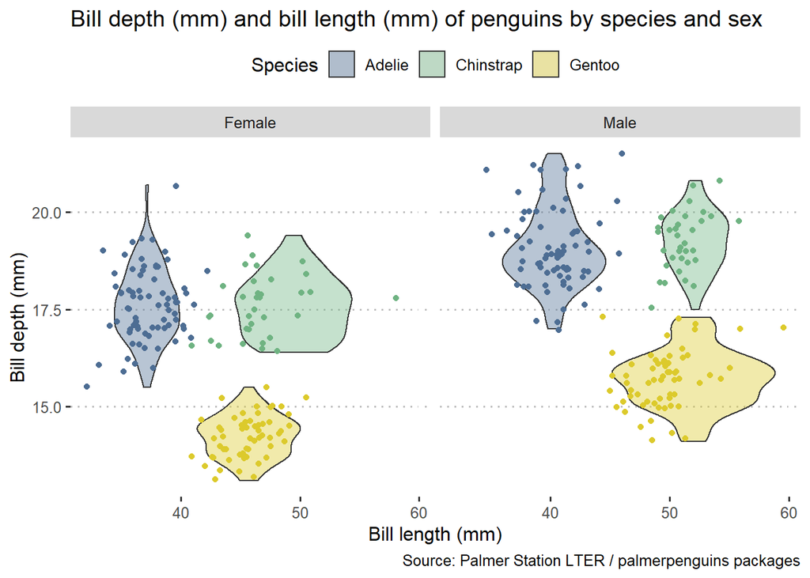

```r
penguins <- na.omit(penguins) %>% #remove NAs in sex column
  mutate(sex = recode(sex, "female" = "Female", "male" = "Male"))
#recode names so properly capitalized in facet


ggplot(data = penguins, #data from palmer penguins
       mapping = aes(x = bill_length_mm, #set x and y axes
                     y = bill_depth_mm)) +
  geom_violin(aes(fill = species), alpha = 0.4) + #set fill to species and alpha value for violin plots
  geom_jitter(aes(color = species)) + #set geom jitter color to species
  guides(color = FALSE) + #remove guide for jitter points because redundant
  facet_wrap(~sex) + #facet by sex
    theme_pubclean() + #set theme
  #set title, axis titles, legend title, and caption
    labs(title = "Bill depth (mm) and bill length (mm) of penguins by species and sex",
         x = "Bill length (mm)",
         y = "Bill depth (mm)",
         fill = "Species",
         caption = "Source: Palmer Station LTER / palmerpenguins packages") +
  #set fill and color scale to specific colors in ghibli palette
  scale_fill_manual(values = ghibli_palette("YesterdayMedium")[c(4, 5, 6)]) +
  scale_color_manual(values = ghibli_palette("YesterdayMedium")[c(4, 5, 6)])
```